# CSC 453

Winter 2026 Day 8

## Admin

- Quiz due Friday
- Lab (synchronization and deadlock) due Monday

# Primitives

## Questions to consider

- How do synchronization solutions compare in implementation / function?
- Why can busy-waiting primitives cause problems like priority inversion, and how do blocking primitives help address this?
- When would you choose a counting semaphore versus a binary semaphore or mutex, and what distinguishes them?

## Semaphores

- Synchronization tool that provides more sophisticated ways (than mutex locks) for processes to synchronize their activities
- Semaphore `S`: integer variable
- Can only be accessed via two atomic operations
  - `wait()` and `signal()`
    - Originally called `P()` and `V()` (because, Dutch - another Dijkstra invention)
- Do not have ownership, any thread can signal (increment) or wait (decrement)

```c
wait(S) {
    while (S <= 0)
       ; // busy
    S--;
}

signal(S) {
    S++;
}
```

## Semaphores (cont’d)

- Binary semaphore: integer value can range only between 0 and 1
  - Functionally the same as a mutex (often when people call something a mutex it’s actually a binary semaphore)

```c
do{
  wait(mutex);
  //CS
  signal(mutex);
}while(TRUE);
```

- Counting semaphore: integer value can range over an unrestricted domain
  - When would this make sense?
    - Protect a finite set of resources rather than a single one (e.g., you have a pool of db connections that can be shared by processes)
    - Initialize `S` to the number of resources
    - Decrement `S` each time someone grabs a resource, increment when they release

## Semaphores (cont’d)

- Can also be used to force synchronization
- Consider $P_1$ and $P_2$ that with two statements $S_1$ and $S_2$ and the requirement that $S_1$ to happen before $S_2$

```c
P1:
   S1;
   signal(sync);
P2:
   wait(sync);
   S2;
```

## Blocking semaphores

- We add `sleep()` and `wakeup()` to the underlying implementation
- Call to wait, and semaphore not available, process is blocked with `sleep()` (wait state) and placed on a waiting queue
- Blocked processes are notified of an available semaphore by the `wakeup()` operation
  - goes from waiting to ready
  - Able to achieve bounded wait and progress with FIFO queue

```c
wait(semaphore *S) {
   S->value--;
   if (S->value < 0) {
      add process to S->list;
      sleep();
   }
}

signal(semaphore *S) {
   S->value++;
   if (S->value <= 0) {
      remove P from S->list;
      wakeup(P);
   }
}
```

## Mutexes vs. semaphores

- Mutexes are generally lighter weight / faster
- Semaphores can support multiple instances
- Semaphores don’t have the ownership limitations

## Choose your primitive

- For each, choose between: atomic instructions; futexes; spin lock mutexes; semaphores
- Scenario 1: You need to protect a critical section where only one thread should execute at a time, and the critical section is expected to be held for a relatively long duration.
  - Futex
- Scenario 2: You have a pool of database connections, and you need to limit the number of threads that can access these connections simultaneously.
  - Counting semaphore

## Choose your primitive (cont’d)

- For each, choose between: atomic instructions; futexes; spin lock mutexes; semaphores
- Scenario 3: You need to increment a shared counter frequently, and the operation is very quick.
  - Atomic instruction
- Scenario 4: You need to protect a critical section where only one thread should execute at a time, but the critical section is expected to be held for a very short duration.
  - Spin lock mutex

## Beware: mistakes are easy to make

- Incorrect use of semaphore operations
  - wrong order: `signal(mutex)` … `wait(mutex)`
  - repeating: `wait(mutex)` … `wait(mutex)`
  - Omitting of `wait(mutex)` and/or `signal(mutex)`
- Be careful

## Monitors

- Subtle mistakes with semaphores can lead to deadlocks, leading to monitors
- Can think of monitors as a library with an API (abstract data type)
  - Processes share the library, but not internal data (directly)
  - This requires language specific understanding of a monitor (C doesn’t have them, natively)
  - More relevant in languages like Java and other high-level languages that provide built-in monitor support

## Monitors (cont’d)

- Main idea: only one processes can be active within a monitor at any instant
  - Up to the compilers to ensure mutual exclusion on monitor procedures
    - It can use other sync primitives to achieve this: e.g. a semaphore or mutex
  - We’re offloading synchronization correctness to the compiler, (hopefully) lessening the chance for error by the user
- Monitor variables are private

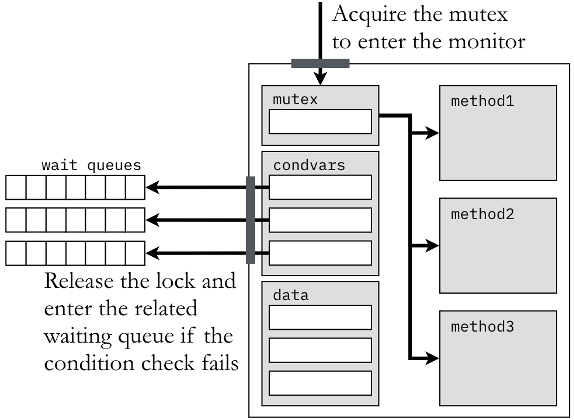

## Condition variables

- Monitors often have condition variables
- Condition variables have `wait()` and `signal()` operations
  - `x.wait()`: a process that invokes the operation is suspended until `x.signal()`
  - `x.signal()`: resumes one of processes (if any) that invoked `x.wait()`
    - If no `x.wait()` on the variable, then it has no effect on the variable
- Big benefit of condition variables: `x.broadcast()`

## Mutexes, semaphores, Monitors, Condition variables

- Mutexes and Semaphores are good for:
  - Simple mutual exclusion
  - Simple counting resources
- Monitors are good for:
  - Complex synchronization between many threads
  - Thread-safe operations (only allow one thread into the monitor at a time)
- Condition variables are good for:
  - Producer-consumer problems (consumer threads waiting on some condition, signaled when ready)
  - We want to make one or more threads sleep until a resource is ready

What isn’t clear?

Comments? Thoughts?

# Deadlocks

## Questions to consider

- What are the four necessary conditions for deadlock, and why must all four be present simultaneously?
- How can Resource Allocation Graphs help us visualize and understand when deadlock might occur?
- Why is a cycle necessary but not sufficient for deadlock when there are multiple instances of a resource?

## Deadlocks

- If we’re not careful about dependencies, we might create pathologies that lead to deadlock
  - Like race conditions, may only happen sometimes, making them hard to identify and debug
- Example: Three processes, three resources of the same type, each process requires two resources to make progress
  - This can happen across a network as well, which is particularly hard to diagnose
- Can we detect and resolve these situations? Can we prevent them?

## Deadlock example

- Classic example: Thread1 holds lock L1 and is waiting for lock L2. Thread2 holds L2 and is waiting for L1

  ```
    Thread 1:                       Thread 2:
    pthread_mutex_lock(L1);         pthread_mutex_lock(L2);
    pthread_mutex_lock(L2);         pthread_mutex_lock(L1);
  ```

## Deadlock characteristics

- Definition: A set of processes are deadlocked if each process in the set is waiting for an event that only another process in the set can cause.
  - Resource deadlock is the most common (and what we’ll focus on generally)
  - Communication deadlock: e.g., Process A sends a message to B, then sleeps until reply; Process B sleeps until it receives a message from A; message is lost

## Conditions for deadlock

- Four necessary conditions (simultaneous):
  - **Mutual exclusion**: At least one resource can only be held by one process at a time; this can result in other processes waiting for that resources
  - **Hold and wait**: A process must be holding at least one resource while waiting for other resources (held by other processes)
  - **No preemption**: Resources can only be released voluntarily by a process; Resources cannot be revoked
  - **Circular wait**: A set of $n$ waiting process ${P_0, ..., P_n}$ such that $P_i$ is waiting for resources held by $P_{i+1 \bmod{n}}$
- All must be met, and some imply others: e.g. Circular wait implies hold and wait.

## Deadlock conditions

- Each condition relates to a policy that may or may not be implemented
  - Q: Can a resource be assigned to more than one process?
  - Q: Can a process request multiple resources? Over what period of time?
  - Q: Can resources be preempted, and how?

## Deadlock modeling

- Resource Allocation Graphs: A directed graph, where process and resources are nodes (sometimes circles and squares respectively), and edges are resource allocations & requests
- Graph for

  ```
  Thread 1:                   Thread 2:
  pthread_mutex_lock(L1);     pthread_mutex_lock(L2);
  pthread_mutex_lock(L2);     pthread_mutex_lock(L1);
  ```

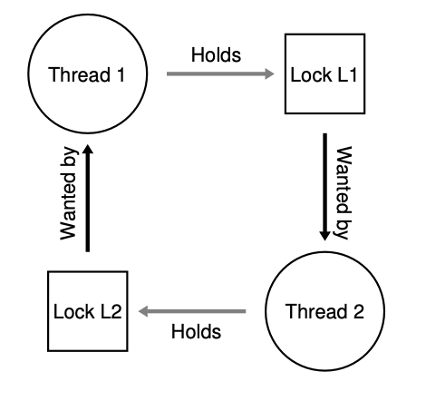

- Cycles in a graph indicate deadlock
  - When resources have only one instance: A cycle is both necessary and sufficient for deadlock
  - **If there are multiple instances: A cycle is necessary but not sufficient for a deadlock**

## Is this deadlocked?

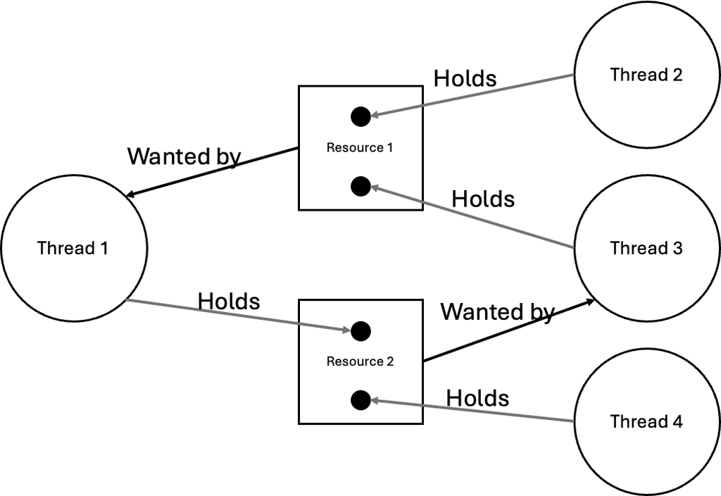

What isn’t clear?

Comments? Thoughts?

# Handling deadlocks

## Questions to consider

- What are the approaches to handling deadlock? How practical is each? How do they differ in approach?
- How does deadlock avoidance differ from deadlock prevention? What techniques do we implement for deadlock avoidance?
- What are the trade-offs between detecting/recovering from deadlock versus preventing or avoiding it, and when is detection practical?

## How should the OS handle deadlocks?

- OS can prevent deadlock: ensure deadlocks can never occur (by preventing one of the deadlock requirements from occurring)
- OS can avoid deadlock: like prevention, but given more information about a processes resource needs
- OS can detect deadlock: allow system to deadlock, detect and recover
- OS can do nothing, and let applications handle it
  - Ostrich Algorithm: head in sand; wait

## Deadlock prevention

- Remember, we just have to break one of these to prevent deadlock
  - Mutual exclusion
  - Hold and wait
  - No preemption
  - Circular wait
- Any ideas?

## Attacking mutual exclusion

- No one resource can only be held by one process at a time; while some resources are preemptable (like memory, through swapping) preventing mutual exclusion is fundamentally difficult as so many resource are non-sharable: printers, files, disks, etc.
  - We can create a monitor for non-preemptable resources (e.g., print spooler, disk drive buffer)

## Attacking hold and wait

- When a process requests a resource, it cannot be holding any other resources
- A process must request **all** of its resources at one time
- Example, treat group of lock acquisitions like a critical section and surround with a mutex

  ```c
  pthread_mutex_lock(global_lock);
  pthread_mutex_lock(L1);
  pthread_mutex_lock(L2);
  ...
  pthread_mutex_unlock(global_lock);
  ```

- See any downsides?
  - Must know all needed locks a priori
  - Will likely decrease concurrency

## Attacking no preemption

- If a process is holding some resources and requests another that cannot be immediately allocated, then all resources held are released
- Process is restarted only when it can regain its old resources plus the new
- Or, if a process requests a resource that cannot be immediately allocated, then all resources held are preempted and added to the list of available resources
- Downsides?
  - Not all resources are preempt-able
  - Starvation is possible

## Attacking circular wait

- How could you prevent by focusing on the circular wait requirement?
- Impose a total ordering of all resource types
  - For example, resource types R1, R2, …, Rn have ordering R1 < R2 < … < Rn
  - A process that needs multiple resources must request them in increasing order of enumeration
- Downsides?
  - May be difficult to impose a meaningful ordering
  - May lead to reduced concurrency

## Deadlock prevention summary

- Which approach is best?
  - Attacking mutual exclusion is generally not feasible
  - Attacking hold and wait is wasteful and requires prescience
  - Attacking no preemption is difficult due to non-preemptable resources
  - Attacking circular wait is practical but may reduce concurrency - often the best choice and [most used](https://github.com/torvalds/linux/blob/f286757b644c226b6b31779da95a4fa7ab245ef5/mm/filemap.c#L80-L126)

What isn’t clear?

Comments? Thoughts?

## Deadlock avoidance

- All of the prevention techniques can be heavy-handed, reducing concurrency and overall system throughput
- What if we had more information about process resource needs before allocation?
  - Could we make smarter decisions about resource allocation?
- This is the idea behind deadlock avoidance

## Avoidance via resource-allocation graph

- Introduce the idea of a claim edge (dashed line) from a process to a resource
  - Indicates that the process may request that resource in the future
- The system can maintain this graph, and only grant resources that will not create a cycle
- Any downsides / limitations?
  - Overhead of maintaining the graph and checking for cycles
  - Only applicable to single instance resources

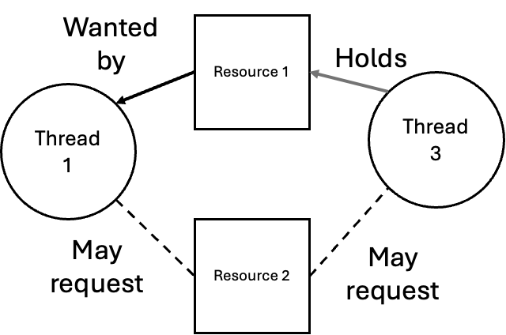

## A note on Dijkstra’s Banker’s algorithm

- Most OS textbooks discuss Dijkstra’s Banker’s algorithm as a deadlock avoidance technique
- Each process must declare the maximum number of resources it may need
- When a process requests a resource, the system must determine if granting the request will leave the system in a safe state
  - A safe state is one where there exists a sequence of all processes such that each can obtain its maximum resources with the currently available resources plus those held by all preceding processes in the sequence
- If granting the request leads to an unsafe state, the process must wait
- Not often used in practice due to overhead and requirement for prescience

## Deadlock avoidance summary

- Do you think any of the avoidance methods are used in general purpose OSes? Why? Why not?
- Resource-allocation graph with claim edges is sometimes used for specific resource types
  - e.g., embedded systems with limited resources where you can predict maximum needs and the graph overhead is manageable
- Banker’s algorithm is generally not used due to its overhead and requirements

## Detecting and recovering from deadlock

- Allow deadlocks to occur, then detect and recover
- In some cases, recovery is pretty simple. If your machine froze once per year (maybe it does?) what would you do?
  - Reboot
- What scenarios do you think complex detection and recovery would make sense?
  - Systems with high availability requirements where manual intervention is costly or impractical
    - telecommunications systems, financial transaction systems, healthcare systems
    - critical infrastructure systems

## Detection

- Use a wait-for graph: a simplified resource-allocation graph that removes resource nodes
  - An edge from process $P_i$ to $P_j$ indicates that $P_i$ is waiting for a resource held by $P_j$
  - A cycle in this graph indicates a deadlock
  - $O(n^2)$ algorithm to search for cycles (beyond the cost of maintaining the graph itself)
  - Only applies to single instance resources

## Detection (cont’d)

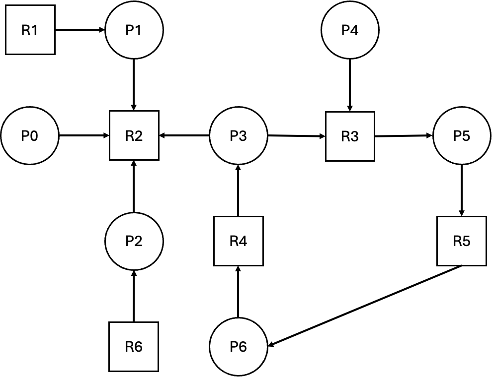

## Detection (cont’d)

- For multiple instance resources, we can use an algorithm similar to the Banker’s algorithm to detect deadlock
- Question: How often should we run the detection algorithm?
  - Too often: wasteful overhead
  - Not often enough: long delays before recovery
  - What if we run it when a process requests a resource?
    - Could allow us to assign blame for deadlock to the requesting process
  - Heuristically (CPU utilization, etc.)
    - Less overhead, but harder to assign blame

## Recovery options

- Process termination
  - Abort all deadlocked processes (brute force)
  - Abort one process at a time until deadlock is resolved
    - How to choose which process to abort?
      - Priority, time running, resources used, etc.
- Resource preemption
  - Temporarily take resources away from some processes and give to others until deadlock is resolved
  - Highly dependent on the resource type
  - Rollback problem - processes may need to be rolled back to a safe state before resources can be reallocated
  - Starvation problem - same victims may be chosen repeatedly

## Handling deadlocks summary

- When to use which technique?
  - Prevention: when you can afford to limit concurrency and throughput for simplicity
  - Avoidance: when you have good information about process resource needs and can afford the overhead
  - Detection and recovery: when deadlocks are rare and the overhead of prevention/avoidance is unjustified
  - Do nothing: when deadlocks are extremely rare or tolerable and can be handled at the application level

What isn’t clear?

Comments? Thoughts?